# Ford GoBike System Data Exploration

## by Karma Dolma Gurung

This presentation showcases summary of exploratory analysis of 1.3 million bike trips taken with Ford GoBike System from Jan 2020 to Jun 2020 covering the greater San Francisco Bay area.

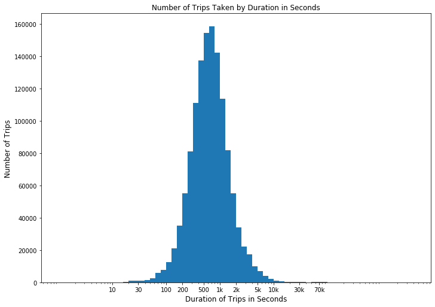

```python
# Let's transform the duration_sec of dataframe 'df'
log_binsize = 0.1
bins = 10 ** np.arange(0, np.log10(df['duration_sec'].max())+log_binsize, log_binsize)

plt.figure(figsize=[ 11.69, 8.27])
plt.hist(data = df, x = 'duration_sec', bins = bins)
plt.xscale('log')
plt.xticks([10, 30, 100, 200, 500, 1e3, 2e3, 5e3, 10e3, 30e3, 70e3],[10, 30, 100, 200, 500, '1k', '2k', '5k', '10k','30k','70k'])
plt.xlabel('Duration of Trips in Seconds',fontsize=12)
plt.ylabel('Number of Trips',fontsize=12)
plt.title('Number of Trips Taken by Duration in Seconds',fontsize=12)
plt.show()
```

On average, the duration of each trips that were taken were around 500 secs roughly 8 minutes.

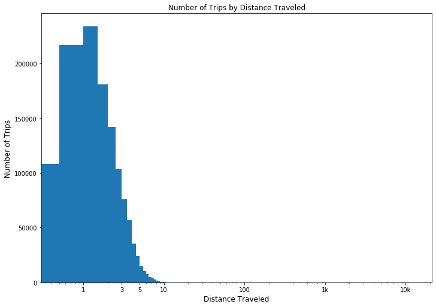

```python
#Plotting histogram using bin size
binsize = 0.5
bins = np.arange(0, df['distance_traveled'].max()+binsize, binsize)

plt.figure(figsize=[ 11.69, 8.27])
plt.hist(data = df, x = 'distance_traveled', bins = bins)
plt.xscale('log')
plt.xlabel('Distance Traveled',fontsize=12)
plt.ylabel('Number of Trips',fontsize=12)
plt.xticks([1, 3, 5, 10, 1e2, 1e3, 1e4],[1, 3, 5, 10, 100 , '1k', '10k'])
plt.title('Number of Trips by Distance Traveled',fontsize=12)
plt.show();
```

On average, the distance traveled for each trip was around 1km.

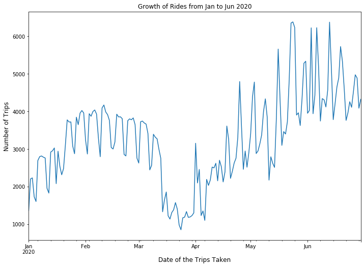

```python
#Plotting line chart for start_date
plt.figure(figsize=[ 11.69, 8.27])
df.groupby('start_date').unique_id.nunique().plot()
plt.xlabel('Date of the Trips Taken',fontsize=12)
plt.ylabel('Number of Trips',fontsize=12)
plt.title('Growth of Rides from Jan to Jun 2020',fontsize=12);
```

There has been a steady growth of number of bike rides in the first half of the year. The dip in the number of bike rides between the end of March and beginning of April was possibly as a result of the Covid pandemic lockdown.

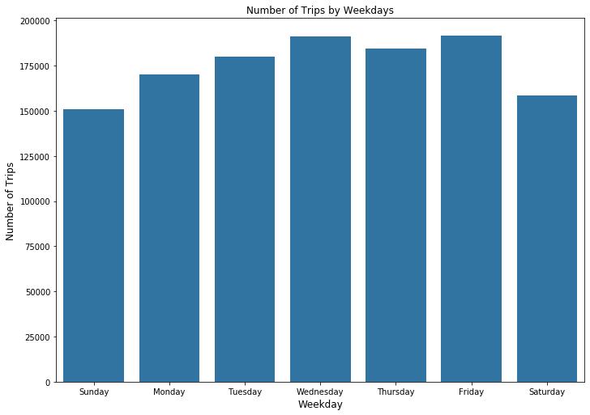

```python
#Creating a bar chart to explore variable "weekday"
weekday_ord = ["Sunday","Monday","Tuesday","Wednesday","Thursday","Friday","Saturday"]
plt.figure(figsize=[ 11.69, 8.27])
x = df['weekday'].unique()

# Return the Series having frequency count of each unique value
y = df['weekday'].value_counts()

base_color = sb.color_palette()[0]

sb.countplot(data=df, x='weekday', color=base_color, order=weekday_ord);

plt.xlabel('Weekday',fontsize=12)
plt.ylabel('Number of Trips',fontsize=12)
plt.title('Number of Trips by Weekdays',fontsize=12)

# Display the plot
plt.show()
```

Weekdays have more trips compared to weekends.

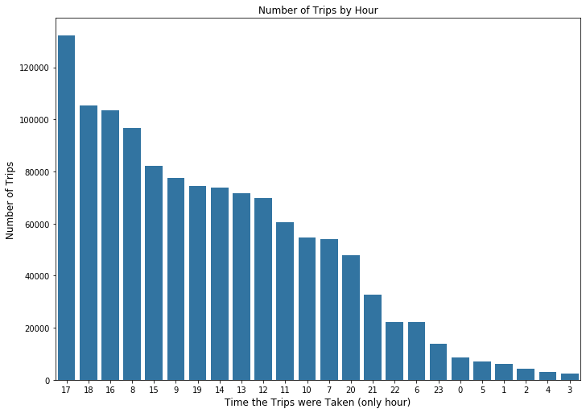

```python
#Creating a bar chart to explore variable "start_hour"
plt.figure(figsize=[ 11.69, 8.27])
x = df['start_time_hour'].unique()

# Return the Series having frequency count of each unique value
y = df['start_time_hour'].value_counts()

gen_order = y.index
base_color = sb.color_palette()[0]

sb.countplot(data=df, x='start_time_hour', color=base_color, order=gen_order);

plt.xlabel('Time the Trips were Taken (only hour)',fontsize=12)
plt.ylabel('Number of Trips',fontsize=12)
plt.title('Number of Trips by Hour',fontsize=12)

# Display the plot
plt.show()
```

The highest number of trips were taken on 5pm, 6pm and 4pm.

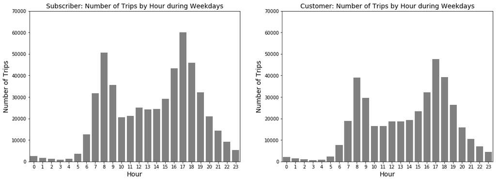

```python
#Side by side comparison of Number of Trips taken by Subscriber and Customer during Weekdays

plt.figure(figsize = [18, 6])

df_Subscriber = df.query('user_type == "Subscriber"')
df_Customer = df.query('user_type == "Customer"')
# left plot: scatterplot of discrete data with jitter and transparency for df_Subscriber
plt.subplot(1,2,1)
fig1 = sb.countplot(x= 'start_time_hour', data = df_Subscriber.query('weekday == "Monday" or weekday == "Tuesday" or weekday == "Wednesday" or weekday == "Thursday" or weekday == "Friday"'), color='Grey')
plt.title('Subscriber: Number of Trips by Hour during Weekdays',fontsize=14)
plt.xlabel('Hour',fontsize=14)
plt.ylabel('Number of Trips',fontsize=14)
plt.ylim([0,70000])

# right plot: scatterplot of discrete data with jitter and transparency for df_Customer
plt.subplot(1,2,2)
fig2 = sb.countplot(x= 'start_time_hour', data = df_Customer.query('weekday == "Monday" or weekday == "Tuesday" or weekday == "Wednesday" or weekday == "Thursday" or weekday == "Friday"'), color='Grey')
plt.title('Customer: Number of Trips by Hour during Weekdays',fontsize=14)
plt.xlabel('Hour',fontsize=14)
plt.ylabel('Number of Trips',fontsize=14)
plt.ylim([0,70000]);
```

The above chart is a side by side comparison of the number of trips taken by Subscriber vs Customer by Hour. Although both chart shows that the highest number of trips were on 8am and 5pm, Subscribers in general have higher number of trips compared to Customers.

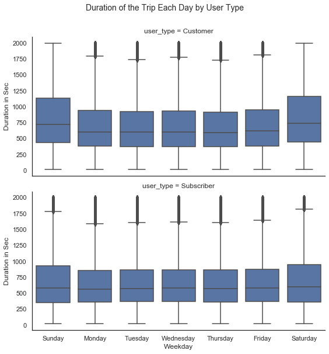

```python
#Analysing the relationship between "user_type", "weekday" and "duration_sec" variables
sb.set()
sb.set_style(style='white')
g = sb.FacetGrid(data = df.query('duration_sec < 2000 & distance_traveled < 15'), col = 'user_type',col_wrap=1, height = 4, aspect= 2)
g.map_dataframe(sb.boxplot, 'weekday', 'duration_sec', order= weekday_ord)
g.fig.suptitle('Duration of the Trip Each Day by User Type', y=1.05,fontsize=14)
g.set_xlabels("Weekday")
g.set_ylabels("Duration in Sec");
```

Subscribers take less time to travel the same distance as compared to Customers. Saturday and Sunday have longer trips for both Customers and Subscribers.

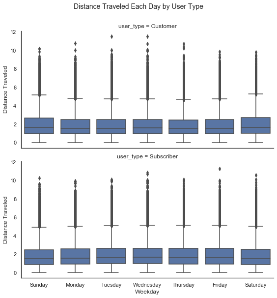

```python
#Analysing the relationship between "user_type", "weekday" and "duration_sec" variables
sb.set()
sb.set_style(style='white')
g = sb.FacetGrid(data = df.query('duration_sec < 2000 & distance_traveled < 15'), col = 'user_type',col_wrap=1, height = 4, aspect= 2)
g.map(sb.boxplot, 'weekday', 'distance_traveled', order= weekday_ord)
g.fig.suptitle('Distance Traveled Each Day by User Type', y=1.05,fontsize=14)
g.set_xlabels("Weekday")
g.set_ylabels("Distance Traveled");
```

On average, the distance traveled for most of the days for both Customers and Subscribers are around 1.5km.

# Conclusion

- Weekdays see more usage than on Weekends.
- 5pm sees the highest usage of the bike.
- Saturdays and Sundays on average take longer time for the same distance compared to Weekdays.
- Subscribers take lesser time to travel the same distance compared to Customers.